# Yushi’s Teaching Experience

17 March, 2022

## Courses at Princeton as an AI

### QCB508 / QCB408 / Foundations of Statistical Genomics

```
Course ID: QCB 508 / QCB 408

Title: Foundations of Statistical Genomics

Semester: 2022 Spring

Instructor: Dr. John D. Storey
```

#### 3.1 Course Website: [Canvas](https://princeton.instructure.com/courses/7114)

#### 3.2 Office Hour Recap

*Preface: This is a brief summary based on the conversations during Yushi’s office hour in Spring 2022. Due to the pandemic, we needed to hold our office hours virtually for this semester. I was unable to provide detailed proof or answers without a blackboard. I listed these details here and I hope that they can help our friends to learn something.*

**Mar 17, 2022**

$\underline{Understand\,\,distribution\,\,of\,\,a\,\,random\,\,variable\,\,(a\,\,simplified\,\,version)}$

$\underline{Lemma}$. Let $(\Omega,\mathcal{F},\mathbb{P})$ be a probability space, $(E,\mathcal{E})$ a measurable space, $A$ an event in $\mathcal{E}$. Define the indicator function
$$\begin{equation}\mathbb{1}_{A}=\mathbb{1}_{A}(X) = \mathbb{1}_{A}\circ X = \begin{cases} 1, \,\,\,\text{if } X\in A,\\0, \,\,\,\text{if } X\notin A. \end{cases} \end{equation}$$
Then
$$\begin{equation}
\mathbb{P}(X\in A)=\mathbb{E}[\mathbb{1}_{A}].
\end{equation}$$

*Proof.* Intuitively
$$\begin{equation}
\mathbb{P}(X\in A) = \mathbb{P}(X\in A)\cdot 1 + \mathbb{P}(X\notin A)\cdot 0 = \mathbb{P}(\mathbb{1}_{A}=1)\cdot 1 + \mathbb{P}(\mathbb{1}_A=0)\cdot 0 = \sum_i i \cdot \mathbb{P}(\mathbb{1}_A=i) = \mathbb{E}[\mathbb{1}_{A}].
\end{equation}$$

**Mar 15, 2022**

$\underline{Understand\,\,distribution\,\,of\,\,a\,\,random\,\,variable\,\,by\,\,integrals}$

$\underline{Notations}$. Let $(\Omega,\mathcal{F},\mathbb{P})$ be a probability space, $(E,\mathcal{E})$ be a measurable space. Expectations of random variable $X:\Omega\mapsto E$ can be interpreted as integrals with respect to $\mathbb{P}$. Let $\mu$ be the distribution of $X$. We can interpret $\mu$ as the image of $\mathbb{P}$ under $X$. To better understand the red text, let $\mu=\mathbb{P}\circ X^{-1}$ while defining mapping $\mathbb{P}\circ X^{-1}:\mathcal{E}\mapsto \bar{\mathbb{R}}_{+}$ by
$$\begin{equation}
\mathbb{P}\circ X^{-1}(A) = \mathbb{P}\big(X^{-1}(A)\big),\,\,\,\,\,\,A\in \mathcal{E},
\end{equation}$$
which is a measure on $(E,\mathcal{E})$. For event $A\in \mathcal{E}$, we write the probability that $X$ is in $A$ as
$$\begin{equation}
\mu(A) = \mathbb{P}\circ X^{-1}(A) = \mathbb{P}\big(X^{-1}(A)\big) = \mathbb{P}(X\in A) = \mathbb{P}\{\omega \in \Omega:X(\omega) \in A\},
\end{equation}$$
which is the image of $\mathbb{P}$ under $X$. Note that $X^{-1}(A)$ denotes the event for every $A$ in $\mathcal{E}$. i.e., $X^{-1}(A) = \{X\in A\} = \{\omega \in \Omega:X(\omega) \in A\}$. It also suggests that $X$ is measurable relative to $\mathcal{F}$ and $\mathcal{E}$.

$\underline{Theorem}$. Let function $f:E\mapsto \Omega$ be measurable relative to $\mathcal{E}$ and $\mathcal{F}$. We define the composition $Y=f\circ X$, which is a random variable taking values in $(\Omega, \mathcal{F})$ by
$$\begin{equation}
Y(\omega) = f\circ X(\omega) = f\big(X(\omega)\big),\,\,\,\,\,\,\text{for}\,\,\,\omega \in \Omega.
\end{equation}$$
If $f$ is positive $\mathcal{E}$-measurable, then
$$\begin{equation}
\mathbb{E}[f\circ X] = \int_{\Omega}\mathbb{P}(d\omega)f\big(X(\omega)\big) = \int_{\Omega} f\big(X(\omega)\big) d\mathbb{P} = \mathbb{P}(f\circ X) = (\mathbb{P}\circ X^{-1})(f) = \mu(f).
\end{equation}$$
Notice that $\mathbb{P}(f\circ X) = (\mathbb{P}\circ X^{-1})(f)$ holds since the function $g(f)=\mathbb{P}(f\circ X)$, which is a mapping $g: \mathcal{E}_{+}\mapsto \bar{\mathbb{R}}_{+}$, satisfies that $g(f)=\mu(f)$ for a unique measure $\mu$ on $(E,\mathcal{E})$ according to the integral characterization theorem. More specifically, this unique measure $\mu$ is $\mathbb{P}\circ X^{-1}$ due to the fact that $\mu(A)=g(\mathbb{1}_{A})=\mathbb{P}(\mathbb{1}_A\circ X)=\mathbb{P}\big(X^{-1}(A)\big)=\mathbb{P}\circ X^{-1}(A)$ for $A\in \mathcal{E}$. Check the corollary below for detailed definition of $\mathbb{1}_{A}\circ X$.

$\underline{Corollary}$. Define the indicator function
$$\begin{equation}\mathbb{1}_{A}(X) = \mathbb{1}_{A}\circ X = \begin{cases} 1, \,\,\,\text{if } X\in A,\\0, \,\,\,\text{if } X\notin A. \end{cases} \end{equation}$$
Notice that $\mathbb{1}_{A}$ is positive $\mathcal{E}$-measurable. Let $f=\mathbb{1}_{A}$, then we write $\mu$, the distribution of $X$, as
$$\begin{equation}
\mu(A) = \mu (\mathbb{1}_{A}) = \mathbb{E}[\mathbb{1}_{A}\circ X],
\end{equation}$$
which is the integral understanding of the distribution of a random variable. A useful application of this corollary is to calculate the p.d.f., i.e., to characterize the distribution, of a random variable when having prior information regarding the target random variable conditioning on other variables. Let us take a look at the following example.

$\underline{Example\,\,(Distribution\,\,of\,\,random\,\,genotype)}.$ Let $X$ be the random genotype in the random-allele-frequency model. We want to characterize the distribution of $X$ but the only information we know is the conditional distribution of $X$ given individual-allele-frequency $\pi$, written as $X|\pi \sim \text{Binomial}(2,\pi)$. Here $\pi$ comes from some other distributions. A strong candidate for this is BN$(p,f)$. We can use the above corollary to derive the distribution of $X$. There are three possible outcomes of $X$ as 0, 1, or 2. For event $A_0=\{\omega\in \Omega: X(\omega)=0\}$, we have
$$\begin{align}
\mathbb{P}(X=0) &= \mathbb{P}(X\in A_0)= \mathbb{P}(X\in A_0)\cdot 1 + \mathbb{P}(X\notin A_0)\cdot 0 =\mathbb{E}[\mathbb{1}_{A_0} \circ X] = \mathbb{E}\big[\mathbb{E}[\mathbb{1}_{A_0}\circ X|\pi]\big] \nonumber \\
&= \mathbb{E}\big[\mathbb{E}[\mathbb{1}_{X=0}|\pi]\big] = \mathbb{E}\big[(1-\pi)^2\big] = \cdots
\end{align}$$
The remaining path can be walked through by following $\mathbb{E}[Z^2]=(\mathbb{E}[Z])^2+\mathbb{V}(Z)$ while taking $Z=1-\pi$. The same strategy yields $\mathbb{P}(X=1)$ and $\mathbb{P}(X=2)$.

**Feb 24, 2022**

$\underline{Conditional\,\,distribution\,\,to\,\,model\,\,the\,\,allele\,\,evolution\,\,in\,\,finite\,\,population}$

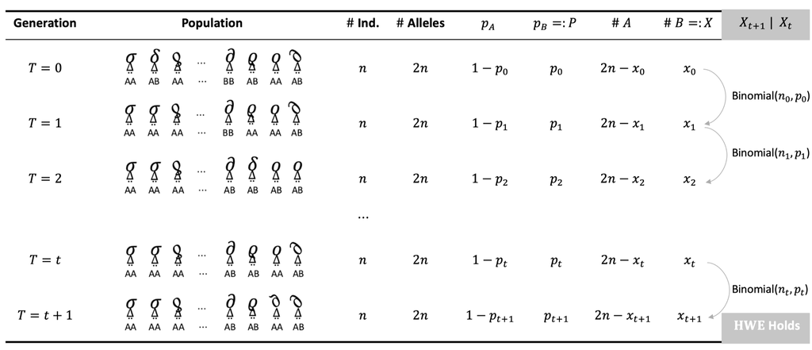

**Feb 22, 2022**

$\underline{Basics\,\,of\,\,IBD\,\,model:\,\,dissemble\,\,genotype\,\,into\,\,alleles}$

Let $X$ and $Y$ be two genotypes at the same loci drawn randomly from a population under the identical-by-descent (IBD) model with allele frequency $p$ and inbreeding coefficient $f$. We are interested in evaluating the covariance between genotype $X$ and $Y$. Recall that IBD is defined based on alleles, i.e., the probability that two alleles are IBD. Hence a basic setup is to decompose $X$ and $Y$ into alleles level. Suppose $X$ is supported by two alleles $X_1$ and $X_2$, $Y$ is supported by two alleles $Y_1$ and $Y_2$. Suppose $X_1$ (and $Y_1$) comes from the maternal side and $X_2$ (and $Y_2$) comes from the paternal side. We write
$$X=X_1+X_2,\,\,\,\,\,\,Y=Y_1+Y_2,$$
thereby deriving their covariance
$$\begin{align}
\text{Cov}(X,Y) &= \text{Cov}(X_1+X_2, Y_1+Y_2) \nonumber \\
&= \mathbb{E}[(X_1+X_2)(Y_1+Y_2)]-\mathbb{E}[X_1+X_2]\mathbb{E}[Y_1+Y_2] \nonumber \\
&= \mathbb{E}[X_1Y_1]+\mathbb{E}[X_1Y_2]+\mathbb{E}[X_2Y_1]+\mathbb{E}[X_2Y_2] - \mathbb{E}[X_1]\mathbb{E}[Y_1]-\mathbb{E}[X_1]\mathbb{E}[Y_2]-\mathbb{E}[X_2]\mathbb{E}[Y_1]-\mathbb{E}[X_2]\mathbb{E}[Y_2] \nonumber \\
&= (\mathbb{E}[X_1Y_1]-\mathbb{E}[X_1]\mathbb{E}[Y_1]) + (\mathbb{E}[X_1Y_2]-\mathbb{E}[X_1]\mathbb{E}[Y_2]) + (\mathbb{E}[X_2Y_1]-\mathbb{E}[X_2]\mathbb{E}[Y_1]) + (\mathbb{E}[X_2Y_2]-\mathbb{E}[X_2]\mathbb{E}[Y_2]) \nonumber \\
&= \text{Cov}(X_1,Y_1) + \text{Cov}(X_1,Y_2) + \text{Cov}(X_2,Y_1) + \text{Cov}(X_2,Y_2) = \sum_{j=1}^2 \sum_{i=1}^2 \text{Cov}(X_i,Y_j) \nonumber \\
&= 4\text{Cov}(X_1,Y_1).
\end{align}$$

The last line holds since all 4 terms of covariance in line 5 are equal.

**Feb 15, 2022**

$\underline{Hints\,\,for\,\,the\,\,law\,\,of\,\,total\,\,variance}$

Let us begin by proving a simple version of the law of total variance

$$\begin{align}
\mathbb{V}(X) &= \mathbb{E}\big[(X-\mathbb{E}[X])^2\big] \nonumber \\
&= \mathbb{E}\big[(X-\mathbb{E}[X|Y]+\mathbb{E}[X|Y]-\mathbb{E}[X])^2\big] \nonumber \\
&= \Big\{\mathbb{E}\big[(X-\mathbb{E}[X|Y])^2\big] + 2\mathbb{E}\big[(X-\mathbb{E}[X|Y])(\mathbb{E}[X|Y]-\mathbb{E}[X])\big] \Big\}+ \mathbb{E}\big[(\mathbb{E}[X|Y]-\mathbb{E}[X])^2\big] \nonumber \\
&= \Big\{\mathbb{E}[X^2]-\mathbb{E}[(\mathbb{E}[X|Y])^2]\Big\} + \mathbb{E}\big[(\mathbb{E}[X|Y]-\mathbb{E}[\mathbb{E}[X|Y]])^2\big] \nonumber \\
&= \mathbb{E}\big[\mathbb{E}[X^2|Y]-(\mathbb{E}[X|Y])^2\big] + \mathbb{V}(\mathbb{E}[X|Y]) \nonumber \\
&= \mathbb{E}[\mathbb{V}(X|Y)] + \mathbb{V}(\mathbb{E}[X|Y]).
\end{align}$$

Line 1 (expand the variance/covariance term by definition) and line 2 (little trick to introduce the conditional term) may provide hints for proving the following equation

$$\begin{equation}
\text{Cov}(X,Y)=\mathbb{E}[\text{Cov}(X,Y|Z)]+\text{Cov}(\mathbb{E}[X|Z],\mathbb{E}[Y|Z]).
\end{equation}$$

More specifically, try to think about two questions: 1) what is the math definition of $\text{Cov}(X,Y)$; 2) how to introduce the conditional terms into the expanded version of $\text{Cov}(X,Y)$. More details for deriving the first term in line 4 from line 3

$$\begin{align}
\mathbb{E}\big[(X-\mathbb{E}[X|Y])\big]&=\mathbb{E}[X^2]-2\mathbb{E}\big[X\mathbb{E}[X|Y]\big]+\mathbb{E}\big[(\mathbb{E}[X|Y])^2\big] \nonumber \\
2\mathbb{E}\big[(X-\mathbb{E}[X|Y])(\mathbb{E}[X|Y]-\mathbb{E}[X])\big] &= 2\mathbb{E}\big[X\mathbb{E}[X|Y]\big]-2\mathbb{E}\big[XE[X]\big]-2\mathbb{E}\big[(\mathbb{E}[X|Y])^2\big]+2\mathbb{E}\big[\mathbb{E}[X|Y]\mathbb{E}[X]\big] \nonumber \\
&= 2\mathbb{E}\big[X\mathbb{E}[X|Y]\big]-2(\mathbb{E}[X])^2-2\mathbb{E}\big[(\mathbb{E}[X|Y])^2\big]+2(\mathbb{E}[X])^2 \nonumber \\
&= 2\mathbb{E}\big[X\mathbb{E}[X|Y]\big]-2\mathbb{E}\big[(\mathbb{E}[X|Y])^2\big] \nonumber \\
\Rightarrow \mathbb{E}\big[(X-\mathbb{E}[X|Y])\big]+ 2\mathbb{E}\big[(X-\mathbb{E}[X|Y])(\mathbb{E}[X|Y]-\mathbb{E}[X])\big] &= \mathbb{E}[X^2]-\mathbb{E}\big[(\mathbb{E}[X|Y])^2\big].
\end{align}$$

## Courses at Harvard as a TA

### STAT215 / STAT115 / BST282 / Introduction to Computational Biology and Bioinformatics

```
Course ID: STAT 215 / STAT 115 / BST 282

Title: Introduction to Computational Biology and Bioinformatics

Semester: 2019 Spring

Instructor: Dr. X. Shirley Liu
```

#### 2.1 Course Website: [Canvas](https://canvas.harvard.edu/courses/49497)

#### 2.2 Evaluation: [Students’ comments](https://github.com/YushiFT/yushift.github.io/tree/master/en/teaching) about Prof. Liu and me

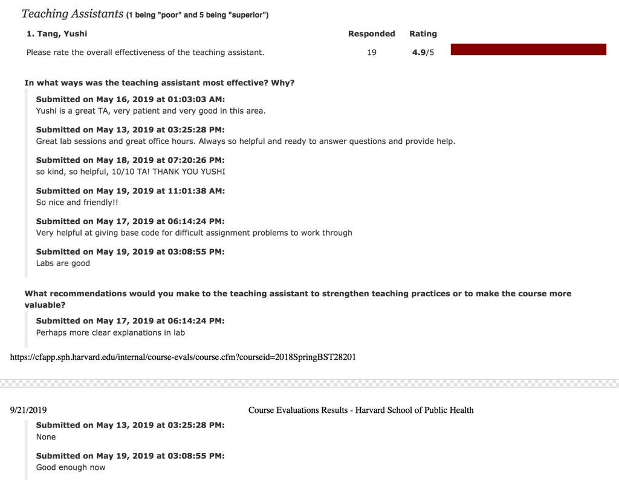

#### 2.3 Chapters Instructed by Me:

###### Lab 5: Bioinformatic Tools for RNA-seq Analysis, DESeq2, and Cluster Computing ( [video](https://www.youtube.com/watch?v=mz64t8-xWgg&list=PL1LC4fx-wvLcqOtVMp48f9kVaGA9JQLLP&index=3&t=4s) and [material](https://github.com/stat115/Lab5) )

###### Lab 6: Single Cell RNA-seq Analysis and Optimizing I/O Performance on the Cluster ( [video 1](https://www.youtube.com/watch?v=8lZXWAmg9sE&list=PL1LC4fx-wvLcqOtVMp48f9kVaGA9JQLLP&index=3), [video 2](https://www.youtube.com/watch?v=CidSoNLWXUg&list=PL1LC4fx-wvLcqOtVMp48f9kVaGA9JQLLP&index=4) and [material](https://github.com/stat115/Lab6) )

###### Lab 7: ChIP-seq data analysis, Bedtools, UCSC Genome Browser, Cistrome and Odyssey ( [video](https://www.youtube.com/watch?v=US5DPGkUBbQ&list=PL1LC4fx-wvLcqOtVMp48f9kVaGA9JQLLP&index=5) and [material](https://github.com/stat115/Lab7) )

###### Lab 8: BETA, VCF, ChIP-seq Motifs Analysis ( [video](https://www.youtube.com/watch?v=QbIXoj2Us1w&list=PL1LC4fx-wvLcqOtVMp48f9kVaGA9JQLLP&index=6) and [material](https://github.com/stat115/Lab8) )

###### Lab 9: Hidden Markov Model and TCGA Data ( [video 1](https://www.youtube.com/watch?v=Z-mC-8RDD9U&list=PL1LC4fx-wvLcqOtVMp48f9kVaGA9JQLLP&index=7), [video 2](https://www.youtube.com/watch?v=_8FrxmIYVK4&list=PL1LC4fx-wvLcqOtVMp48f9kVaGA9JQLLP&index=8) and [material](https://github.com/stat115/Lab9) )

###### Lab 10: GWAS, HaploReg, RegulomeDB, Regression, and Feature Selection ( [video](https://www.youtube.com/watch?v=48coCc6RXzI&list=PL1LC4fx-wvLcqOtVMp48f9kVaGA9JQLLP&index=9) and [material](https://github.com/stat115/Lab10) )

### BST215 / Linear and Longitudinal Regression

```
Course ID: BST 215

Title: Linear and Longitudinal Regression

Semester: 2018 Summer

Instructor: Dr. Garrett Fitzmaurice
```

#### 1.1 Course Website: [Canvas](https://canvas.harvard.edu/courses/41831)

#### 1.2 Evaluation: [Students’ comments](https://github.com/YushiFT/yushift.github.io/blob/master/en/teaching/BST215_Evaluation.pdf) about Prof. Fitzmaurice and me

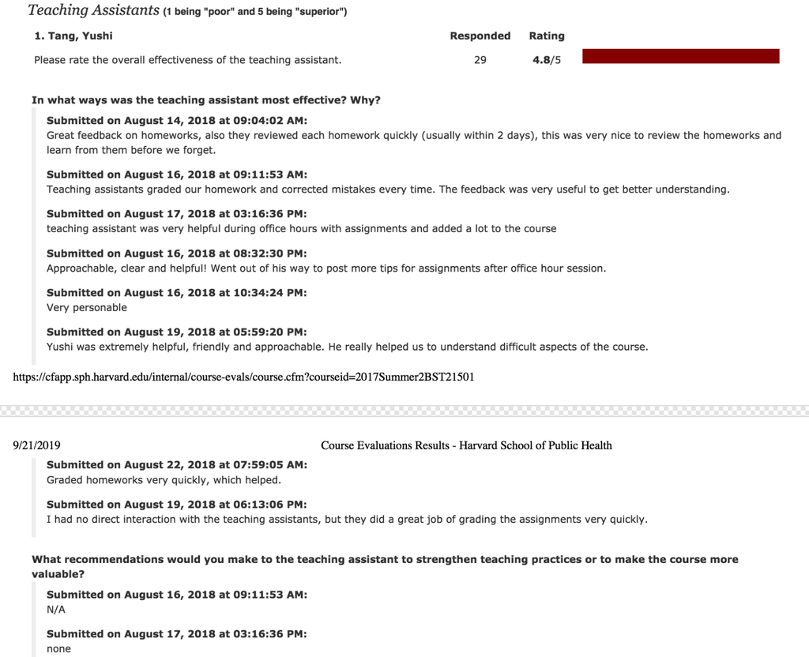

## [Back to Home](https://yushift.github.io)

[Homepage](https://yushift.github.io)